# Inferring spatial gene expression patterns using the MERFISH ST reference (Mouse hypothalamic preoptic region)

Yang

2024-09-04

### Setup

```r
library(limma)
library(Seurat)
library(readr)
library(tidyverse)
library(magrittr)
library(pander)
library(SingleCellExperiment)
library(reshape2)
library(BayesSpace)
library(MuSiC)
library(ggplot2)
library(ggpubr)
library(Matrix.utils)

theme_set(theme_bw())
panderOptions("big.mark", ",")
panderOptions("table.split.table", Inf)
panderOptions("table.style", "rmarkdown")
if (interactive()) setwd(here::here("analysis"))
```

### Summary

To demonstrate a broad application of Palette, we plan to use MERFISH data as the ST reference and evaluate the performance of Palette. Here we present a tutorial using MERFISH data as the ST reference to infer the spatial gene expression in the mouse hypothalamus region. The inferred expression patterns will then be compared to the original expression of the MERFISH ST data.

Note: Palette only takes the overlapped genes for inference, and thus only the genes present in the MERFISH reference can be inferred.

### Load data

Load the hypothalamus bulk data (Liao et al., 2022) and the MERFISH ST reference (Moffitt et al., 2018).

```r
bulk <- read.delim(here::here("test","mouse_hypothalamus_bulk.txt"), header = T) %>% column_to_rownames(var = "GENE")
MERFISH_st <- readRDS(here::here("test","mouse_hypothalamus_MERFISH.rds"))
```

### MERFISH ST slices

Here we visualize the MERFISH slice and each ST spot is colored with spot annotation.

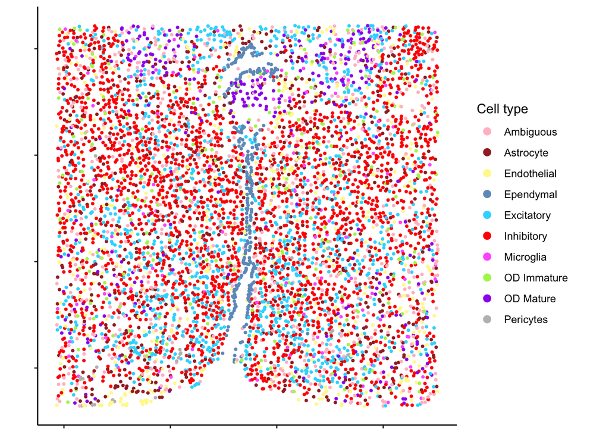

The MERFISH slice.

```r
ggplot(MERFISH_st@meta.data %>% as.data.frame(),aes(x=Centroid_X, y=Centroid_Y, color=Cell_class)) +
  geom_point(size=0.7) +
  theme_classic() +
    coord_fixed(ratio = 1, xlim = NULL, ylim = NULL, expand = TRUE, clip = "on") +
  scale_color_manual(values = levels(MERFISH_st@meta.data$color %>% as.factor())) +
  theme_classic() +
  theme(axis.text.x=element_blank(),
        axis.text.y=element_blank(),
        axis.title.x=element_blank(),
        axis.title.y=element_blank()) +
  scale_color_manual(name="Cell type",values = c("pink", "brown", "#FFF799", "#6e9BC5", "#2ED9FF","red" ,"#ff66ff","#AEF359", "purple","grey")) +
  guides(colour = guide_legend(override.aes = list(size=2.5)))
```

### Select the overlapped genes and take the stable genes for spatial clustering and deconvolution.

We take the overlapped genes in the bulk dataset and MERFISH ST reference, and then select stable genes for spatial clustering and deconvolution. Since only only a few hundred genes are present in MERFISH dataset, we choose the top 50 genes closest to the mean and median ratios as stable genes for the subsequent analyses. Given the high expression levels detected by MERFISH, we do not apply any filtering to the expression data in the analyses.

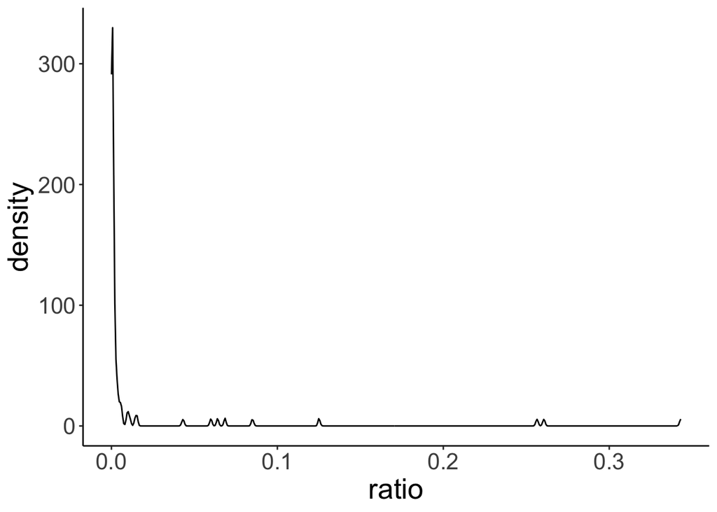

Density plot showing the expression ratio of bulk and MERFISH ST reference

```r
MERFISH_st <- MERFISH_st[rownames(bulk),]

slice_sum <- colSums(t(MERFISH_st@assays$RNA@counts)) %>% as.data.frame() %>%
  set_colnames("expression")

bulk_reorder <- bulk[rownames(MERFISH_st),,drop=F]

# Define the ratio of the bulk and the aggregate ST as gene filter
gene_filter <- bulk_reorder/slice_sum %>%
  .[is.finite(rowSums(.)),, drop = FALSE]
colnames(gene_filter) <- "ratio"

ggplot(gene_filter, aes(x=ratio)) +
  geom_density() + theme_classic() +
  theme(text = element_text(size = 20))
```

```r
# The difference of gene ratio to the mean and median ratio
gene_filter$differ <- abs(gene_filter$ratio - (mean(gene_filter$ratio)+median(gene_filter$ratio))/2)
# Select the top 50 genes closer to the mean and median for spatial clustering and deconvolution
stable_genes <- gene_filter %>%
  .[order(.$differ),] %>%
   top_n(.,-50)
```

### Spatial clustering of ST data

BayesSpace is employed for spatial clustering on MERFISH ST data. Only the selected 50 stable genes are used for spatial clustering. The cluster identities are then assigned to each ST spot.

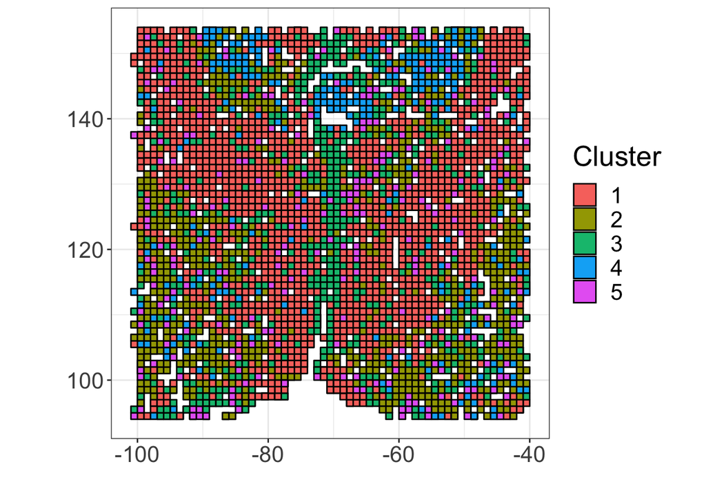

Spatial Clustering of MERFISH ST reference

```r
# Convert coordinates into pixel coordinates for BayesSpace
metadata <-  MERFISH_st@meta.data
metadata$col <-  (metadata$Centroid_X/30 %>% as.numeric()) %>% as.integer()
metadata$row <-  (metadata$Centroid_Y/30 %>% as.numeric()) %>% as.integer()

# Construct sce object
sce <- SingleCellExperiment(assays = list(counts = MERFISH_st@assays$RNA@counts, logcounts = MERFISH_st@assays$RNA@data),
                            colData=metadata)

# Only take stable genes for spatial clustering
sce_filtered <- sce[rownames(stable_genes),]
sce_filtered <- spatialPreprocess(sce_filtered, platform="ST",
                              n.PCs=4,n.HVGs = 2000, log.normalize=TRUE)
# Select the number of clusters
p <- qTune(sce_filtered, qs=seq(2, 10), platform="ST")

# Clustering with BayesSpace
set.seed(149)
spatial_cluster <- spatialCluster(p, q=5, platform="ST", d=7,
                           init.method="kmeans", model="t", gamma=2,
                           nrep=10000, burn.in=100,
                           save.chain=TRUE)

# Visualizing spatial clusters
clusterPlot(spatial_cluster, color="black") +
  theme_bw() +
  xlab("") +
  ylab("") +
  theme(text = element_text(size = 20))
```

```r
MERFISH_st$spatial_cluster <- spatial_cluster$spatial.cluster
Idents(MERFISH_st) <- MERFISH_st$spatial_cluster

# Check the proportions of each cluster
prop_table <- prop.table(table(MERFISH_st$spatial_cluster)) %>% t()
colnames(prop_table) <- c("cluster 1","cluster 2","cluster 3","cluster 4","cluster 5")
rownames(prop_table) <- "Proportion"
knitr::kable(prop_table,
             caption = "The proportions of each cluster.")
```

The proportions of each cluster.

|  | cluster 1 | cluster 2 | cluster 3 | cluster 4 | cluster 5 |
| --- | --- | --- | --- | --- | --- |
| Proportion | 0.4408515 | 0.2151446 | 0.1767956 | 0.0797855 | 0.0874228 |

### bulk deconvolution to estimate cell type abundances

MuSiC is employed for deconvolution. Also, only the selected 50 stable genes are used for deconvolution. We can then achieve the abundances of each cluster in pseudo bulk data.

```r
# Pre-process data for MuSiC
bulk$rep <- bulk$CTGTGTGGACATTTGGAC
bulk.est <- Biobase::ExpressionSet(assayData = bulk %>% as.matrix())
sc.eset <- ExpressionSet(assayData = as.matrix(GetAssayData(MERFISH_st)), phenoData = new("AnnotatedDataFrame", MERFISH_st@meta.data))

MERFISH_st$sample_id <- colnames(MERFISH_st)
sce <- SingleCellExperiment(assays = list(counts = MERFISH_st[rownames(stable_genes),]@assays$RNA@counts, logcounts = MERFISH_st[rownames(stable_genes),]@assays$RNA@data),
                            colData=MERFISH_st[rownames(stable_genes),]@meta.data)

# MuSiC deconvolution
Est.pro = music_prop(bulk.mtx = exprs(bulk.est), sc.sce = sce,  clusters = "spatial_cluster", samples = "sample_id")
proportion <- Est.pro$Est.prop.weighted
proportion_reorder <- proportion[, c("1","2","3","4","5")]

# The estimated proportion of each cluster in pseudo bulk data
prop_table_2 <- proportion_reorder[2,] %>% t()
colnames(prop_table_2) <- c("cluster 1","cluster 2","cluster 3","cluster 4","cluster 5")
rownames(prop_table_2) <- "Proportion"
knitr::kable(prop_table_2,
             caption = "The estimated proportions of each cluster in bulk data.")
```

The estimated proportions of each cluster in bulk data.

|  | cluster 1 | cluster 2 | cluster 3 | cluster 4 | cluster 5 |
| --- | --- | --- | --- | --- | --- |
| Proportion | 0.1809347 | 0.580054 | 0.0467548 | 0.0921029 | 0.1001537 |

### Variable factor calculation

Here we define a variable factor to adjust the expression difference between bulk and MERFISH ST reference. The variable factor is defined as the ratio of bulk expression matrix to the pseudo bulk matrix, which is constructed by the cluster expression of MERFISH data and cluster abundance of bulk. Each gene has its own variable factor to adjust its expression.

```r
# The average gene expression of each cluster
cluster.averages <- AverageExpression(MERFISH_st) %>%
  as.data.frame() %>%
  as.matrix()

cluster.averages_filtered <- cluster.averages %>%
  as.data.frame() %>%
  rownames_to_column() %>%
  dplyr::filter(.$rowname %in% rownames(bulk)) %>%
  column_to_rownames(var= "rowname")  %>%
  as.matrix() %>%
  .[,c("RNA.1","RNA.2","RNA.3","RNA.4","RNA.5")]

# The abundance of each cluster in pseudo bulk
abundance <- proportion_reorder %>%
  .[2,,drop=FALSE] %>%
  as.data.frame() %>%
  as.matrix()


bulk_reorder <- bulk[match(rownames(cluster.averages_filtered), rownames(bulk)),1,drop=FALSE] %>%
  as.data.frame()

# Define variable factor
variable_factor <- (bulk_reorder/(cluster.averages_filtered %*% (abundance %>% t()))) %>%
  .[is.finite(rowSums(.)),, drop = FALSE] %>%
  as.data.frame() %>%
  set_colnames("var")

variable_factor_matrix <- rep(variable_factor,5) %>%
  as.data.frame() %>%
  set_colnames(c("1","2","3","4","5"))
rownames(variable_factor_matrix) <- rownames(variable_factor)
```

```
## [1] "The top 5 rows of variable factor"
```

```
##                  var
## Adcyap1 1.863080e+01
## Adora2a 3.739091e-04
## Aldh1l1 4.941268e-27
## Amigo2  1.436206e-36
## Ano3    5.151070e-01
```

The adjusted matrix is the overall gene expression of each cluster, which is obtained by taking the dot product of the cluster expression matrix of ST slice and the variable factor.

```r
adjusted_matrix <- ((cluster.averages_filtered[rownames(variable_factor_matrix),] * variable_factor_matrix))
colnames(adjusted_matrix) <- c("cluster 1","cluster 2","cluster 3","cluster 4","cluster 5")
```

```
## [1] "The top 5 rows of adjusted matrix"
```

```
##            cluster 1    cluster 2    cluster 3    cluster 4    cluster 5
## Adcyap1 9.407822e-01 1.130938e+00 6.644130e-01 7.612660e-01 7.248435e-01
## Adora2a 2.275108e-04 3.903542e-01 3.845248e-04 1.605198e-04 7.723125e+00
## Aldh1l1 1.440079e-14 5.049828e-14 1.497173e+02 3.682559e-20 6.379910e-17
## Amigo2  4.021101e-11 1.723977e+00 9.997774e-28 2.485198e-20 1.499972e-24
## Ano3    2.083917e+01 6.500741e+00 1.570275e+00 3.011482e-01 3.569886e+00
```

### Estimate expression of each spot

The expression of each spot is estimated through a loop algorithm. In each interaction of the loop, the procedure begins by selecting one random spot and its neighboring spots. The number of neighboring spots can be changed depending on the data. The expression of spots belonging to the same cluster is aggregated to form a pseudo bulk data called regional cluster ST (RST).

Here we assume that the ratio of RST to the entire ST data is equal to the ratio of the adjusted RST to the adjusted matrix. We define the ratio of RST to the entire ST as regional factor K. The adjust regional ST equals to the dot product of adjusted matrix and regional factor K. The expression of adjusted RST is then evenly allocated into the selected spots of this cluster. After thousands of interactions, the average expression of each spot is almost stable and considered as the output estimated expression.

```r
#### Construct the MERFISH data to a pseudo bulk
slice_sce <- SingleCellExperiment(assays = list(counts = MERFISH_st@assays$RNA@counts),
                           colData = MERFISH_st@meta.data)
groups <- colData(slice_sce)[, c("Animal_ID")]
slice_bulk <- aggregate.Matrix(t(counts(slice_sce)),
                       groupings = groups, fun = "sum") %>%
  as.data.frame() %>% t()


ST <- slice_bulk %>%
  as.data.frame() %>%
  set_colnames("Counts") %>%
  rownames_to_column() %>%
  dplyr::select(Gene=rowname, Counts)

#### Nearest 24 spots
#### Due to the thousands of ST spots, we take 25 spots as a region.
output_final <- data.frame(matrix(ncol = 0, nrow = length(rownames(variable_factor_matrix))))
rownames(output_final) <- rownames(variable_factor_matrix)
for (i in 1:5000) {
  # Select one random spot
  set.seed(i)
  random.obj <- MERFISH_st[, sample(colnames(MERFISH_st), size = 1, replace=F)]
  spot <- random.obj@meta.data[,c("Centroid_X","Centroid_Y")] %>% as.data.frame()
  df <- MERFISH_st@meta.data[,c("Centroid_X","Centroid_Y")] %>% as.data.frame()
  # Calculate the distance from other spots to the selected spot
  df$distance = sqrt((df$Centroid_X - spot$Centroid_X)^2 + (df$Centroid_Y - spot$Centroid_Y)^2)
  # Here we select the nearest 24 spots. The number of the nearest spots can be changed here.
  df <- df[order(df$distance),][1:25,]
  random.neighbor <-  MERFISH_st[,rownames(df)]
  output_region <- data.frame(matrix(ncol = 0, nrow = length(rownames(variable_factor_matrix))))
  rownames(output_region) <- rownames(variable_factor_matrix)
  # For each cluster in the selecting spots
  for (k in as.numeric(levels(as.factor(random.neighbor$spatial_cluster)))){
    # Select the spots belonging to the same cluster
    cluster <- subset(random.neighbor, subset = spatial_cluster == k)
    # Sum the expression of these spots from the same cluster
    RST <- colSums(t((cluster@assays$RNA@counts))) %>%
      as.data.frame() %>%
      rownames_to_column() %>%
      dplyr::select(Gene=rowname, Counts = '.')
    # Define a regional factor K as the ratio of RST to ST
    K <- RST$Counts/ST$Counts %>%
      as.data.frame()
    rownames(K) <- ST$Gene
    K_filtered <- K %>%
      rownames_to_column() %>%
      dplyr::select(Gene=rowname, factor = '.') %>%
      dplyr::filter(.$Gene %in% rownames(variable_factor_matrix)) %>%
      column_to_rownames(var= "Gene")  %>%
      as.matrix()
    # Adjusted regional bulk equals to the dot product of adjusted matrix and regional factor K
    region_bulk <- (adjusted_matrix[,k] %>% as.data.frame()) * K_filtered
    # Assign expression to each spot
    each_spot <- data.frame(region_bulk/length(cluster$orig.ident))
    output <- cbind(each_spot, rep(each_spot[1],  length(cluster$orig.ident)))
    output <- output[1:(length(output)-1)]
    colnames(output) <- rownames(cluster@meta.data)
    output_region <- output_region %>%
      cbind(output)
    }
  output_final <- output_final %>%
    cbind(output_region)
}

# Calculate the average expression of each spot
cell_list <- as.list(rownames(MERFISH_st@meta.data))

spot_average_counts_final <- data.frame(matrix(ncol = 0, nrow = length(rownames(variable_factor_matrix))))
rownames(spot_average_counts_final) <- rownames(variable_factor_matrix)
spot_rep_times <- data.frame()

for ( i in 1:length(cell_list)) {
  spot <- colnames(output_final) == cell_list[i]
  spot_counts <- output_final[, spot, drop = FALSE]
  spot_rep_times <- spot_rep_times %>%
    rbind(length(colnames(spot_counts)))
  spot_average_counts <-  data.frame(rowSums(spot_counts))/length(spot_counts)
  colnames(spot_average_counts) <- cell_list[i]
  spot_average_counts_final <- spot_average_counts_final %>%
    cbind(spot_average_counts)
}

# Covert Palette-inferred data into seurat object
MERFISH_ST_adjusted <- CreateSeuratObject(spot_average_counts_final,assay = "RNA",meta.data = metadata)
MERFISH_ST_adjusted@images$image <- MERFISH_st@images$image
saveRDS(MERFISH_ST_adjusted, here::here("test","MERFISH_ST_adjusted.rds"))
```

### Palette performance assessment

We assess the Palette performance through comparing the expression patterns of Palette implemented data to original ST data. Here we show the expression patterns of marker genes Syt4 (Inhibitory neurons) and Mlc1 (Ependymal cells). Compared to the original ST data (Left), the Palette-implemented data (Right) significantly increases the signal-to-noise ratio and exhibits more specific expression patterns. Although the inferred expression levels are much lower due to the lower detection levels in the bulk dataset, our Palette pipeline successfully captures the major gene expression patterns.

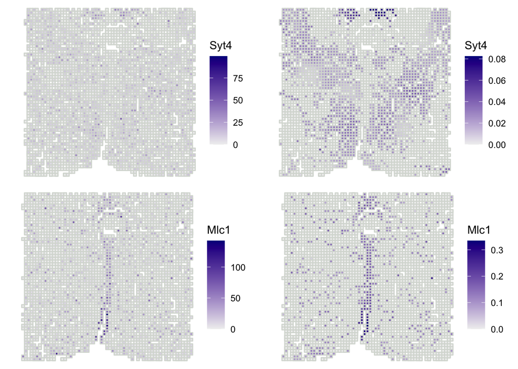

Comparsion of expression patterns.

```r
# Construct sce object for expression visualization
metadata <-  MERFISH_ST_adjusted@meta.data
metadata$col <-  MERFISH_ST_adjusted@meta.data$col
metadata$row <-  MERFISH_ST_adjusted@meta.data$row


sce_MERFISH <- SingleCellExperiment(assays = list(counts = MERFISH_ST_adjusted@assays$RNA@counts, logcounts = MERFISH_ST_adjusted@assays$RNA@data),
                            colData= metadata)

sce_MERFISH <- spatialPreprocess(sce_MERFISH, platform="ST",
                              n.PCs=4,n.HVGs = 2000, log.normalize=FALSE,skip.PCA=TRUE)


p1 <- featurePlot(
  sce_MERFISH,
  "Syt4",
  assay.type = "logcounts",
  diverging = FALSE,
  low = NULL,
  high = "darkblue",
  mid = NULL,
  color = NULL,
  platform = NULL,
  is.enhanced = NULL,
)

p2 <- featurePlot(
  sce_MERFISH,
  "Mlc1",
  assay.type = "logcounts",
  diverging = FALSE,
  low = NULL,
  high = "darkblue",
  mid = NULL,
  color = NULL,
  platform = NULL,
  is.enhanced = NULL,
)


sce_ST <- SingleCellExperiment(assays = list(counts = MERFISH_st@assays$RNA@counts, logcounts = MERFISH_st@assays$RNA@data),
                            colData=metadata)

sce_ST <- spatialPreprocess(sce_ST, platform="ST",
                              n.PCs=4,n.HVGs = 2000, log.normalize=FALSE,skip.PCA=TRUE)

p3 <- featurePlot(
  sce_ST,
  "Syt4",
  assay.type = "logcounts",
  diverging = FALSE,
  low = NULL,
  high = "darkblue",
  mid = NULL,
  color = NULL,
  platform = NULL,
  is.enhanced = NULL,
)

p4 <- featurePlot(
  sce_ST,
  "Mlc1",
  assay.type = "logcounts",
  diverging = FALSE,
  low = NULL,
  high = "darkblue",
  mid = NULL,
  color = NULL,
  platform = NULL,
  is.enhanced = NULL,
)

ggarrange(p3, p1, p4, p2, ncol = 2, nrow = 2)
```